# Estudis d'Informàtica, Multimedia i Telecomunicacions

# Mineria de dades: PAC1

Autor: Guillem Pla Bertran

Octubre 2022

# 1 Exercici 1:

> El projecte de mineria de dades proposat és un estudi sobre dades de diverses estacions meteorològiques. Aquestes estacions estan repartides per una regió relativament petita. Estan connectades a internet i poden enviar les seves dades en temps real a un o diversos ordinadors.

> La primera fase consisteix a definir la tasca. El propòsit d’aquesta fase és saber què es vol aconseguir i definir quin tipus de projecte de mineria de dades és (trobar similituds, classificar, predir, descriure o explicar). En aquest cas, l’objectiu és predir la temperatura d’un indret de la regió on no hi hagi cap estació. D’aquesta forma es podrien estalviar molts recursos, ja que no caldria instal·lar més estacions.

> La segona fase consisteix a fer una selecció de les dades. En aquesta fase es busca obtenir les dades necessàries per a poder dur a terme el projecte. Això no sempre és una tasca fàcil, perquè no sempre s’emmagatzemen les dades amb la finalitat de ser analitzades. En aquest cas, cal obtenir les dades en cru dels diversos ordinadors on estan emmagatzemades. Tanmateix, també es podria intentar buscar altres dades d’estacions, encara que no pertanyin a la mateixa regió. La idea seria intentar tenir el màxim de dades possible.

> La tercera fase consisteix a preparar les dades per a poder ser tractades. Aquesta fase és molt important perquè si no, per molt esforç que es posi en la creació de models, no s’aconseguiran resultats satisfactoris. Per tant, cal assegurar-se que les dades tenen prou qualitat, que siguin les necessàries i que estiguin en la forma adequada. Per a assolir això cal netejar-les, transformar-les i reduir-ne la dimensionalitat. Com ja s’ha comentat anteriorment, en el projecte plantejat les estacions meteorològiques capten les dades i les envien en temps real a un altre ordinador mitjançant internet. Tenint en compte aquestes circumstàncies, és molt possible que les dades no sempre siguin prou bones. Pot passar que els sensors no estiguin ben calibrats, que s’hagi espatllat momentàniament algun sensor, que durant un temps s’hagi perdut la connexió a internet (i, per tant, les dades). Per tot això, cal fer una anàlisi exhaustiva de les dades per a poder detectar quins registres són incomplets i quins són inconsistents. Un cop detectats, s’hauran de tractar per eliminar-los o aplicar algun mètode (com calcular la mitjana dels valors) per substituir-los. Un cop es disposi de dades netes, les dades ja es podran transformar. Segons el model que es pretengui fer servir més endavant, caldrà normalitzar les dades. També es poden discretitzar els valors per a millorar la velocitat en el procés d’entrenament i reduir l’emmagatzematge, entre d’altres. Per tancar aquesta fase, el que es pot fer és reduir la dimensionalitat de les dades. Com que l’objectiu és predir la temperatura en un indret, és possible que alguns atributs no siguin rellevants per a generar el model final i que alguns atributs siguin equivalents. Per tant, cal fer-ne una selecció dels més útils.

> La quarta fase consisteix a crear els models. La fita d’aquesta etapa és cercar el model que tingui un millor resultat per al nostre propòsit. En conseqüència, cal explorar el conjunt de models possibles i avaluar-los correctament per a poder decidir quin és l’adequat. És molt probable que comprovar tots els models possibles sigui impossible, doncs, el que es fa és començar per pocs models i modificar-los progressivament per a poder intuir quin d’ells donarà millor resultat. En aquest cas, es podrien provar models com els arbres de decisió, la regressió lineal i logística i les xarxes neuronals, ja que, aquest es fan servir sovint en projectes predictius. Per a avaluar els models creats s’haurà de crear una mètrica que penalitzi en funció de la distància entre el valor predit i el valor real.

> Finalment, l’última i cinquena fase consisteix a integrar els resultats. El que es vol en aquest punt és posar en marxa tota la feina realitzada. Cal desenvolupar un programa que permeti executar el model generat i que retorni la informació adequada. En el cas del projecte proposat, caldria dissenyar una API que retorni les prediccions segons l’indret seleccionat. Un cop dissenyada aquesta API, es podria integrar fàcilment dins d’una pàgina web.

> És important tenir en compte que les fases descrites no cal que s’executin de forma seqüencial. El més habitual és que el procés es faci de forma iterativa.

# 2 Exercici 2:

Els accidents de trànsit són una de les pricipals causes de mort de qualsevol país. És per això, que es destinen molts recursos en diferents àmbits a paliar els efectes dels accidents. Com a analistes de dades, podem intentar aportar el nostre gra de sorra i intentar reduir la quantitat de morts a la carretera.

L’objectiu d’aquest projecte és intentar explicar i aportar nou coneixement sobre els accidents de cotxe mortals. La idea final és que se’n puguin extreure conclusions per a ajudar conductors i administracions a reduïr ferits, morts i danys materials.

## 2.1 Descripció de les dades

Les dades escollides són les recopilades per la [National Highway Traffic Safety Administration (NHTSA)](https://www.nhtsa.gov/). Són una organització governamental dels Estats Units d’Amèrica que tenen per objectiu salvar vides, evitar lesions i reduir els costos econòmics que es deriven dels accidents de trànsit. Ho fan mitjançant l’educació i la recerca, entre altres.

Aquesta associacó publica les dades [Fatality Analysis Reporting System (FARS)](https://www.nhtsa.gov/crash-data-systems/fatality-analysis-reporting-system) que són les que es faran servir en aquesta anàlisi. Les dades es poden trobar [aquí](https://www.nhtsa.gov/file-downloads?p=nhtsa/downloads/FARS/). És un cens d’accidents mortals de trànsit, conté dades de 50 estats dels EUA, el districte de Columbia i Puerto Rico.

Les primeres dades disponibles es remunten a l’any 1975. Això implica que els fitxers presenten diferències entre ells, hi ha alguns paràmetres que s’han discontinuat en el temps i alguns que s’ha canviat la forma de presentar-los. És important tenir en compte que les dades han sigut tractades per un equip d’analistes, és a dir, no són dades en cru i han passat per processos de revisió per a suprimir errors.

Per a que un accident estigui en aquestes dades ha de complir una sèrie de condicions:

- L’accident inclou, com a mínim, un vehicle a motor.
- El vehicle conduia per una carretera oberta al públic.
- Ha acabat en la mort d’algú implicat en l’accident dins dels 30 primers dies des d’aquest.

El conjunt de dades consta de diversos fitxers `.csv`. El més important és `accident.CSV`. Aquest conté la informació bàsica de cada accident. La resta de fitxers aporten informació complementària sobre cada accident.

## 2.2 Entendre les dades

Com s’ha comentat en la secció anterior, el fitxer `accident.CSV` és la base de tot el conjunt de dades. Per tant, es comença l’anàlisi a partir d’aquest.

Primer de tot, cal tenir més informació sobre aquestes dades. És important saber quants registres tenim, quins atributs hi ha, de quin tipus són els atributs. També s’ha de conèixer si les dades contenen errors o camps buits.

Per la documentació disponible es pot saber quins camps estan disponibles, quants n’hi ha i què volen dir:

| **Atribut** | **Descripció** |
| --- | --- |
| STATE | Codi de l’estat on ha passat l’accident |
| STATENAME | Nom de l’estat |
| ST_CASE | Identificador del cas |
| VE_TOTAL | Nombre de vehicles implicats |
| VE_FORMS | Nombre de vehicles de motor en transport |
| PVH_INVL | Nombre de vehicles aparcats o treballant |
| PEDS | Nombre de persones fora de vehicles de motor |
| PERSONS | Nombre de persones en vehicles de motor |
| PERMVIT | Nombre de persones en vehicles de motor en transport |
| PERNOTMVIT | Nombre de persones fora de vehicles de motor en transport |
| COUNTY | Codi del comptat |
| COUNTYNAME | Nom del comptat |
| CITY | Codi de la ciutat |
| CITYNAME | Nom de la ciutat |
| DAY | Dia de l’accident |
| DAYNAME | Dia de l’accident |
| MONTH | Mes de l’accident |
| MONTHNAME | Nom del mes de l’accident |
| YEAR | Any de l’accident |
| DAY_WEEK | Número de la setmana de l’accident |
| DAY_WEEKNAME | Dia de la setmana de l’accident |
| HOUR | Hora de l’accident (24h) |
| HOURNAME | Hora de l’accident (am/pm) |
| MINUTE | Minut de l’accident |
| MINUTENAME | Minut de l’accident |
| NHS | Pertany o no al Sistema Nacional de Carreteres (bool) |
| NHSNAME | Pertany o no al Sistema Nacional de Carreteres |
| ROUTE | Codi de la senyalització de la ruta |
| ROUTENAME | Nom de la senyalització de la ruta |
| TWAY_ID | Identificador de via de trànsit |

[output cut: 51 more lines]

En total tenim 81 atributs. Com es pot observar, la majoria estan repetits, en uns s’hi mostra la codificació i en uns altres s’hi mostra la descripció de la variable.

Ara ja es poden carregar les dades.

```r
path <- "../data/accident.CSV"
accident_data <- read.csv(path, row.names = NULL)

# Guardem una còpia de l'original, que no tocarem, per si l'hem de recuperar més tard
accident_data_original <- accident_data
```

I es pot fer una petita previsualització de les dades.

```r
head(accident_data)
```

```
##   STATE STATENAME ST_CASE VE_TOTAL VE_FORMS PVH_INVL PEDS PERSONS PERMVIT
## 1     1   Alabama   10001        1        1        0    0       4       4
## 2     1   Alabama   10002        4        4        0    0       6       6
## 3     1   Alabama   10003        2        2        0    0       2       2
## 4     1   Alabama   10004        1        1        0    0       5       5
## 5     1   Alabama   10005        1        1        0    0       1       1
## 6     1   Alabama   10006        2        2        0    0       3       3
##   PERNOTMVIT COUNTY     COUNTYNAME CITY       CITYNAME DAY DAYNAME MONTH
## 1          0     51    ELMORE (51)    0 NOT APPLICABLE   1       1     1
## 2          0     73 JEFFERSON (73)  350     BIRMINGHAM   2       2     1
## 3          0    117   SHELBY (117)    0 NOT APPLICABLE   2       2     1
## 4          0     15   CALHOUN (15)    0 NOT APPLICABLE   3       3     1
## 5          0     37     COOSA (37)    0 NOT APPLICABLE   4       4     1
## 6          0    103   MORGAN (103)    0 NOT APPLICABLE   4       4     1
##   MONTHNAME YEAR DAY_WEEK DAY_WEEKNAME HOUR      HOURNAME MINUTE MINUTENAME NHS
```

[output cut: 97 more lines]

A més, també és útil veure’n un resum.

```r
summary(accident_data)
```

```
##      STATE        STATENAME            ST_CASE          VE_TOTAL
##  Min.   : 1.00   Length:35766       Min.   : 10001   Min.   : 1.00
##  1st Qu.:12.00   Class :character   1st Qu.:122078   1st Qu.: 1.00
##  Median :26.00   Mode  :character   Median :260917   Median : 1.00
##  Mean   :27.16                      Mean   :272387   Mean   : 1.56
##  3rd Qu.:42.00                      3rd Qu.:420477   3rd Qu.: 2.00
##  Max.   :56.00                      Max.   :560115   Max.   :15.00
##     VE_FORMS         PVH_INVL             PEDS           PERSONS
##  Min.   : 1.000   Min.   : 0.00000   Min.   :0.0000   Min.   : 0.000
##  1st Qu.: 1.000   1st Qu.: 0.00000   1st Qu.:0.0000   1st Qu.: 1.000
##  Median : 1.000   Median : 0.00000   Median :0.0000   Median : 2.000
##  Mean   : 1.517   Mean   : 0.04269   Mean   :0.2285   Mean   : 2.173
##  3rd Qu.: 2.000   3rd Qu.: 0.00000   3rd Qu.:0.0000   3rd Qu.: 3.000
##  Max.   :15.000   Max.   :10.00000   Max.   :8.0000   Max.   :61.000
##     PERMVIT         PERNOTMVIT         COUNTY        COUNTYNAME
##  Min.   : 0.000   Min.   :0.0000   Min.   :  1.00   Length:35766
##  1st Qu.: 1.000   1st Qu.:0.0000   1st Qu.: 31.00   Class :character
##  Median : 2.000   Median :0.0000   Median : 71.00   Mode  :character
##  Mean   : 2.163   Mean   :0.2387   Mean   : 93.06
##  3rd Qu.: 3.000   3rd Qu.:0.0000   3rd Qu.:117.00
##  Max.   :61.000   Max.   :9.0000   Max.   :999.00
##       CITY        CITYNAME              DAY           DAYNAME
##  Min.   :   0   Length:35766       Min.   : 1.00   Min.   : 1.00
##  1st Qu.:   0   Class :character   1st Qu.: 8.00   1st Qu.: 8.00
##  Median : 120   Mode  :character   Median :16.00   Median :16.00
##  Mean   :1436                      Mean   :15.71   Mean   :15.71
##  3rd Qu.:2080                      3rd Qu.:23.00   3rd Qu.:23.00
##  Max.   :9999                      Max.   :31.00   Max.   :31.00
##      MONTH         MONTHNAME              YEAR         DAY_WEEK
##  Min.   : 1.000   Length:35766       Min.   :2020   Min.   :1.000
##  1st Qu.: 4.000   Class :character   1st Qu.:2020   1st Qu.:2.000
##  Median : 7.000   Mode  :character   Median :2020   Median :4.000
##  Mean   : 6.898                      Mean   :2020   Mean   :4.114
##  3rd Qu.:10.000                      3rd Qu.:2020   3rd Qu.:6.000
##  Max.   :12.000                      Max.   :2020   Max.   :7.000
##  DAY_WEEKNAME            HOUR         HOURNAME             MINUTE
##  Length:35766       Min.   : 0.00   Length:35766       Min.   : 0.00
##  Class :character   1st Qu.: 7.00   Class :character   1st Qu.:14.00
##  Mode  :character   Median :15.00   Mode  :character   Median :30.00
##                     Mean   :13.94                      Mean   :29.24
```

[output cut: 92 more lines]

```
##                     Max.   :99.00                      Max.   :99.00
##  HOSP_HRNAME           HOSP_MN      HOSP_MNNAME            FATALS
##  Length:35766       Min.   : 0.00   Length:35766       Min.   :1.000
##  Class :character   1st Qu.:88.00   Class :character   1st Qu.:1.000
##  Mode  :character   Median :88.00   Mode  :character   Median :1.000
##                     Mean   :80.76                      Mean   :1.085
##                     3rd Qu.:99.00                      3rd Qu.:1.000
##                     Max.   :99.00                      Max.   :8.000
##     DRUNK_DR
##  Min.   :0.0000
##  1st Qu.:0.0000
##  Median :0.0000
##  Mean   :0.2664
##  3rd Qu.:1.0000
##  Max.   :4.0000
```

Finalment, se’n pot visualitzar l’estructura de les dades.

```r
str(accident_data)
```

```
## 'data.frame':    35766 obs. of  81 variables:
##  $ STATE       : int  1 1 1 1 1 1 1 1 1 1 ...
##  $ STATENAME   : chr  "Alabama" "Alabama" "Alabama" "Alabama" ...
##  $ ST_CASE     : int  10001 10002 10003 10004 10005 10006 10007 10008 10009 10010 ...
##  $ VE_TOTAL    : int  1 4 2 1 1 2 1 2 2 2 ...
##  $ VE_FORMS    : int  1 4 2 1 1 2 1 2 2 2 ...
##  $ PVH_INVL    : int  0 0 0 0 0 0 0 0 0 0 ...
##  $ PEDS        : int  0 0 0 0 0 0 1 0 0 0 ...
##  $ PERSONS     : int  4 6 2 5 1 3 1 2 4 3 ...
##  $ PERMVIT     : int  4 6 2 5 1 3 1 2 4 3 ...
##  $ PERNOTMVIT  : int  0 0 0 0 0 0 1 0 0 0 ...
##  $ COUNTY      : int  51 73 117 15 37 103 73 25 45 95 ...
##  $ COUNTYNAME  : chr  "ELMORE (51)" "JEFFERSON (73)" "SHELBY (117)" "CALHOUN (15)" ...
##  $ CITY        : int  0 350 0 0 0 0 330 0 0 1500 ...
##  $ CITYNAME    : chr  "NOT APPLICABLE" "BIRMINGHAM" "NOT APPLICABLE" "NOT APPLICABLE" ...
```

[output cut: 67 more lines]

## 2.3 Preparació de les dades

### 2.3.1 Anàlisi dels atributs buits

Es necessari saber quants valors són buits, ja que, depén de quants valors buits hi hagi a una columna o fila, caldrà aplicar-li un tractament o un altre.

La següent funció mostra quina proporció de dades buides (`""`) o de dades no disponibles (`NA`) hi ha per cada columna, i ho ordena de més a menys.

```r
sort(colMeans(is.na(accident_data) | accident_data == ""), decreasing = TRUE)
```

```
##     TWAY_ID2        STATE    STATENAME      ST_CASE     VE_TOTAL     VE_FORMS
##     0.754823     0.000000     0.000000     0.000000     0.000000     0.000000
##     PVH_INVL         PEDS      PERSONS      PERMVIT   PERNOTMVIT       COUNTY
##     0.000000     0.000000     0.000000     0.000000     0.000000     0.000000
##   COUNTYNAME         CITY     CITYNAME          DAY      DAYNAME        MONTH
##     0.000000     0.000000     0.000000     0.000000     0.000000     0.000000
##    MONTHNAME         YEAR     DAY_WEEK DAY_WEEKNAME         HOUR     HOURNAME
##     0.000000     0.000000     0.000000     0.000000     0.000000     0.000000
##       MINUTE   MINUTENAME          NHS      NHSNAME        ROUTE    ROUTENAME
##     0.000000     0.000000     0.000000     0.000000     0.000000     0.000000
##      TWAY_ID      RUR_URB  RUR_URBNAME     FUNC_SYS FUNC_SYSNAME     RD_OWNER
##     0.000000     0.000000     0.000000     0.000000     0.000000     0.000000
## RD_OWNERNAME       MILEPT   MILEPTNAME     LATITUDE LATITUDENAME     LONGITUD
##     0.000000     0.000000     0.000000     0.000000     0.000000     0.000000
## LONGITUDNAME       SP_JUR   SP_JURNAME      HARM_EV  HARM_EVNAME     MAN_COLL
##     0.000000     0.000000     0.000000     0.000000     0.000000     0.000000
## MAN_COLLNAME      RELJCT1  RELJCT1NAME      RELJCT2  RELJCT2NAME      TYP_INT
##     0.000000     0.000000     0.000000     0.000000     0.000000     0.000000
##  TYP_INTNAME     WRK_ZONE WRK_ZONENAME     REL_ROAD REL_ROADNAME     LGT_COND
##     0.000000     0.000000     0.000000     0.000000     0.000000     0.000000
## LGT_CONDNAME      WEATHER  WEATHERNAME      SCH_BUS  SCH_BUSNAME         RAIL
##     0.000000     0.000000     0.000000     0.000000     0.000000     0.000000
##     RAILNAME     NOT_HOUR NOT_HOURNAME      NOT_MIN  NOT_MINNAME     ARR_HOUR
##     0.000000     0.000000     0.000000     0.000000     0.000000     0.000000
## ARR_HOURNAME      ARR_MIN  ARR_MINNAME      HOSP_HR  HOSP_HRNAME      HOSP_MN
##     0.000000     0.000000     0.000000     0.000000     0.000000     0.000000
##  HOSP_MNNAME       FATALS     DRUNK_DR
##     0.000000     0.000000     0.000000
```

Es pot observar que només un dels camps té valors buits, es tracta del camp `TWAY_ID2` que indica una de les vies on s’ha produit l’accident.

### 2.3.2 Discretizació dels atributs

La discretització consisteix en establir un criteri que permeti dividir els valors d’un atribut en dos o més conjunts disjunts.

Com que aquest conjunt de dades ja ha sigut tractat prèviament, hi ha algunes variables que ja han estat discretitzades. Però, encara pot ser útil discretitzar alguna variable númerica més.

La variable `PEDS` que indica el nombre de vianats implicats en l’accident es pot discretizar, ja que, no aporta gaire informació el nombre total de vianants implicats en l’accident. En aquest cas, és més interessant saber si hi ha hagut vianants implicats o no.

El següent codi transforma els valors més grans que `0` en `1`, i deixa els `0` tal i com estan. Ara, l’atribut `PEDS` conté `0` si no hi va haver cap vianant implicat, i conté `1` si n’hi va haver `1` o més.

```r
if (!require("arules")) install.packages("arules"); library("arules")

accident_data$PEDS <- discretize(accident_data$PEDS, method="fixed", breaks = c(-Inf, 1, Inf), labels = c(0, 1))
summary(accident_data$PEDS)
```

```
##     0     1
## 28130  7636
```

Una altra variable que es pot discretitzar és l’hora en que ha passat l’accident (`HOUR`). Pot ser interessant agrupar les hores pel moment del dia en què ha passat.

```r
accident_data$HOUR_MOMENT <- discretize(accident_data$HOUR, method="fixed", breaks = c(0, 4, 11, 14, 18, 22, 24), labels = c(0, 1, 2, 3, 4, 5))
accident_data$HOUR_MOMENTNAME <- discretize(accident_data$HOUR, method="fixed", breaks = c(0, 4, 11, 14, 18, 22, 24), labels = c("Early morning", "Morning", "Noon", "After noon", "Evening", "Night"))
summary(accident_data$HOUR_MOMENT)
```

```
##    0    1    2    3    4    5 NA's
## 4782 7122 4036 7198 8702 3613  313
```

```r
summary(accident_data$HOUR_MOMENTNAME)
```

```
## Early morning       Morning          Noon    After noon       Evening
##          4782          7122          4036          7198          8702
##         Night          NA's
##          3613           313
```

### 2.3.3 Construcció de variables noves

En el conjunt de dades actual disposem de l’hora de notificació (`NOT_HOUR`, `MIN_HOUR`), l’hora d’arribada dels serveis d’emergències (`ARR_HOUR`, `ARR_MIN`) i l’hora d’arribada de les víctimes a l’hospital (`HOSP_HR`, `HOSP_MN`).

També disposem dels atributs `HOUR` i `MINUTE`, que són l’hora i el minut en que ha passat l’accident.

Aquests atributs poden ser útils, però segurament és més útil saber el temps que ha passat des que ha passat o s’ha notificat l’accident fins que han arribat els serveis d’emergències i fins que s’ha arribat a l’hospital. Per això, en el següent *script* es creen les noves variables.

```r
if (!require("purrr")) install.packages("purrr"); library("purrr")

delta_time <- function(first_time, second_time) {
  delta <- difftime(first_time, second_time, units = "mins")
  delta <- as.numeric(delta)

  if (!is.na(delta) & delta < 0) {
    delta <- difftime(first_time + 86400, second_time, units = "mins")
    delta <- as.numeric(delta)
  }
  return(delta)
}

delta_vector <- function(first_vector, second_vector) {
  if (length(first_vector) != length(second_vector)) {
    return(c())
  }

  result_vector <- c()
  for (i in 1:length(first_vector)) {
    first_time <- first_vector[i]
    second_time <- second_vector[i]
    delta <- delta_time(first_time, second_time)
    result_vector <- c(result_vector, delta)
  }
  return(result_vector)
}

join_hour_min <- function(hour, min) {
  # not interested in year, month. Only in hour min
  time <- paste("1900-01-01 ", hour, ":", min, ":00", sep = "")
  time <- strptime(time, "%Y-%m-%d %H:%M:%S")
  return(time)
}

crash_joined <- join_hour_min(accident_data$HOUR, accident_data$MINUTE)
notification_joined <- join_hour_min(accident_data$NOT_HOUR, accident_data$NOT_MIN)
arrival_joined <- join_hour_min(accident_data$ARR_HOUR, accident_data$ARR_MIN)
hospital_joined <- join_hour_min(accident_data$HOSP_HR, accident_data$HOSP_MN)

crash_arrival <- delta_vector(arrival_joined, crash_joined)
crash_hospital <- delta_vector(hospital_joined, crash_joined)
arrival_hospital <- delta_vector(hospital_joined, arrival_joined)

notification_arrival <- delta_vector(arrival_joined, notification_joined)
notification_hospital <- delta_vector(hospital_joined, notification_joined)
arrival_hospital <- delta_vector(hospital_joined, arrival_joined)

accident_data$DTIME_CRASH_ARRIVAL <- crash_arrival
accident_data$DTIME_CRASH_HOSPITAL <- crash_hospital
```

```r
summary(accident_data$DTIME_CRASH_ARRIVAL)
```

```
##    Min. 1st Qu.  Median    Mean 3rd Qu.    Max.    NA's
##    0.00    6.00   10.00   61.15   18.00 1439.00   20522
```

```r
summary(accident_data$DTIME_CRASH_HOSPITAL)
```

```
##    Min. 1st Qu.  Median    Mean 3rd Qu.    Max.    NA's
##    0.00   28.00   40.00   60.48   58.00 1439.00   28545
```

Un cop executada aquesta funció, es pot observar que molts resultats són `NA`. Això d’entrada pot resultar molt confús, perquè en l’anàlisi realitzat anteriorment hem vist com no hi havia cap `NA`. Això es deu a que els analistes que han tractat aquestes dades han recodificat els `NA` per altres codis. En el cas de les hores `99` significa que no es té dades i `88` vol dir que no aplica.

De moment, no s’inclouen totes les noves variables dins del dataset. Només han sigut incloses les que es consideren més rellevants (`DTIME_CRASH_ARRIVAL`, `DTIME_CRASH_HOSPITAL`).

### 2.3.4 Normalització d’atributs

En principi, no caldria normalitzar cap atribut, ja que, no es faran servir models de xarxes neuronals ni mètodes basats en distàncies.

Tanmateix, se’n poden normalitzar alguns per si més endavant es necessiten. Els atributs que es normalitzen són `FATALS`, `DRUNK_DR`, `VE_TOTAL`, `VE_FORMS`, `PVH_INVL`, `PERSONS`, `PERMVIT`, `PERNOTMVIT`, `DTIME_CRASH_ARRIVAL` i `DTIME_CRASH_HOSPITAL`.

Es fa servir la normalització basada en la desviació estàndard per a tenir en compte la distribució actual dels valors.

```r
selected_attr = c("FATALS", "DRUNK_DR", "VE_TOTAL", "VE_FORMS", "PVH_INVL", "PERSONS", "PERMVIT", "PERNOTMVIT", "DTIME_CRASH_ARRIVAL", "DTIME_CRASH_HOSPITAL")
accident_data_aux <- accident_data[, selected_attr]
accident_data_norm <- as.data.frame(scale(accident_data_aux))

summary(accident_data_norm)
```

```
##      FATALS           DRUNK_DR          VE_TOTAL          VE_FORMS
##  Min.   :-0.2497   Min.   :-0.5796   Min.   :-0.7158   Min.   :-0.7022
##  1st Qu.:-0.2497   1st Qu.:-0.5796   1st Qu.:-0.7158   1st Qu.:-0.7022
##  Median :-0.2497   Median :-0.5796   Median :-0.7158   Median :-0.7022
##  Mean   : 0.0000   Mean   : 0.0000   Mean   : 0.0000   Mean   : 0.0000
##  3rd Qu.:-0.2497   3rd Qu.: 1.5957   3rd Qu.: 0.5622   3rd Qu.: 0.6550
##  Max.   :20.1953   Max.   : 8.1216   Max.   :17.1767   Max.   :18.2985
##
##     PVH_INVL          PERSONS           PERMVIT          PERNOTMVIT
##  Min.   :-0.1458   Min.   :-1.3636   Min.   :-1.3609   Min.   :-0.483
##  1st Qu.:-0.1458   1st Qu.:-0.7360   1st Qu.:-0.7316   1st Qu.:-0.483
##  Median :-0.1458   Median :-0.1085   Median :-0.1023   Median :-0.483
##  Mean   : 0.0000   Mean   : 0.0000   Mean   : 0.0000   Mean   : 0.000
##  3rd Qu.:-0.1458   3rd Qu.: 0.5191   3rd Qu.: 0.5270   3rd Qu.:-0.483
##  Max.   :33.9983   Max.   :36.9184   Max.   :37.0268   Max.   :17.727
##
##  DTIME_CRASH_ARRIVAL DTIME_CRASH_HOSPITAL
##  Min.   :-0.251      Min.   :-0.458
##  1st Qu.:-0.227      1st Qu.:-0.246
##  Median :-0.210      Median :-0.155
##  Mean   : 0.000      Mean   : 0.000
##  3rd Qu.:-0.177      3rd Qu.:-0.019
##  Max.   : 5.661      Max.   :10.439
##  NA's   :20522       NA's   :28545
```

### 2.3.5 Esborrar atributs innecessàris

Com s’ha pogut observar, hi ha moltes variables repetides que només aporten una descripció de les variables categòriques numèriques. És evident que treballar amb tots dos tipus d’atributs alhora és innecessàri, per això, es podria optar per esborrar-ne un tipus o un altre. També es pot fer és tenir dos còpies del *Data Frame*. Un *Data Frame* amb les dades numèriques i un altre amb les dades descriptives, així es pot escollir quin es vol fer servir en cada moment.

El següent codi crea tots dos *Data Frames*. Del conjunt de dades original se’n treu les columnes que no interessen.

```r
numeric_cat_attr <- c("STATE", "COUNTY", "CITY", "DAY", "MONTH", "DAY_WEEK", "HOUR", "MINUTE", "NHS",
                      "ROUTE", "RUR_URB", "FUNC_SYS", "RD_OWNER", "MILEPT", "LATITUDE", "LONGITUD",
                      "SP_JUR", "HARM_EV", "MAN_COLL", "RELJCT1", "RELJCT2", "TYP_INT", "WRK_ZONE",
                      "REL_ROAD", "LGT_COND", "WEATHER", "SCH_BUS", "RAIL", "NOT_HOUR", "NOT_MIN",
                      "ARR_HOUR", "ARR_MIN", "HOSP_HR", "HOSP_MN", "HOUR_MOMENT")
descriptive_cat_attr <- c("STATENAME", "COUNTYNAME", "CITYNAME", "DAYNAME", "MONTHNAME", "DAY_WEEKNAME", "HOURNAME", "MINUTENAME", "NHSNAME",
                      "ROUTENAME", "RUR_URBNAME", "FUNC_SYSNAME", "RD_OWNERNAME", "MILEPTNAME", "LATITUDENAME", "LONGITUDNAME",
                      "SP_JURNAME", "HARM_EVNAME", "MAN_COLLNAME", "RELJCT1NAME", "RELJCT2NAME", "TYP_INTNAME", "WRK_ZONENAME",
                      "REL_ROADNAME", "LGT_CONDNAME", "WEATHERNAME", "SCH_BUSNAME", "RAILNAME", "NOT_HOURNAME", "NOT_MINNAME",
                      "ARR_HOURNAME", "ARR_MINNAME", "HOSP_HRNAME", "HOSP_MNNAME", "HOUR_MOMENTNAME", "TWAY_ID", "TWAY_ID2", "RAIL")

accident_data_numeric <- accident_data[, -which(names(accident_data) %in% descriptive_cat_attr)]
accident_data_names <- accident_data[, -which(names(accident_data) %in% numeric_cat_attr)]

head(accident_data_numeric)
```

```
##   STATE ST_CASE VE_TOTAL VE_FORMS PVH_INVL PEDS PERSONS PERMVIT PERNOTMVIT
## 1     1   10001        1        1        0    0       4       4          0
## 2     1   10002        4        4        0    0       6       6          0
## 3     1   10003        2        2        0    0       2       2          0
## 4     1   10004        1        1        0    0       5       5          0
## 5     1   10005        1        1        0    0       1       1          0
## 6     1   10006        2        2        0    0       3       3          0
##   COUNTY CITY DAY MONTH YEAR DAY_WEEK HOUR MINUTE NHS ROUTE RUR_URB FUNC_SYS
## 1     51    0   1     1 2020        4    2     58   0     4       1        5
## 2     73  350   2     1 2020        5   17     18   0     6       2        4
## 3    117    0   2     1 2020        5   14     55   0     3       1        4
## 4     15    0   3     1 2020        6   15     20   0     4       1        7
## 5     37    0   4     1 2020        7    0     45   0     4       1        5
## 6    103    0   4     1 2020        7   16     55   0     3       1        4
##   RD_OWNER MILEPT LATITUDE  LONGITUD SP_JUR HARM_EV MAN_COLL RELJCT1 RELJCT2
```

[output cut: 27 more lines]

```r
head(accident_data_names)
```

```
##   STATENAME ST_CASE VE_TOTAL VE_FORMS PVH_INVL PEDS PERSONS PERMVIT PERNOTMVIT
## 1   Alabama   10001        1        1        0    0       4       4          0
## 2   Alabama   10002        4        4        0    0       6       6          0
## 3   Alabama   10003        2        2        0    0       2       2          0
## 4   Alabama   10004        1        1        0    0       5       5          0
## 5   Alabama   10005        1        1        0    0       1       1          0
## 6   Alabama   10006        2        2        0    0       3       3          0
##       COUNTYNAME       CITYNAME DAYNAME MONTHNAME YEAR DAY_WEEKNAME
## 1    ELMORE (51) NOT APPLICABLE       1   January 2020    Wednesday
## 2 JEFFERSON (73)     BIRMINGHAM       2   January 2020     Thursday
## 3   SHELBY (117) NOT APPLICABLE       2   January 2020     Thursday
## 4   CALHOUN (15) NOT APPLICABLE       3   January 2020       Friday
## 5     COOSA (37) NOT APPLICABLE       4   January 2020     Saturday
## 6   MORGAN (103) NOT APPLICABLE       4   January 2020     Saturday
##        HOURNAME MINUTENAME                        NHSNAME
```

[output cut: 76 more lines]

## 2.4 Visualització de les dades

Per seguir entenent les dades cal visualitzar-les. Aquesta secció conté una sèrie de gràfics que ajuden a comprendre millor les dades.

### 2.4.1 Lloc de l’accident

El primer que es pot fer és veure on ha succeït cada accident. Per fer-ho es dibuixen tots els accidents sobre el mapa dels Estats Units d’Amèrica.

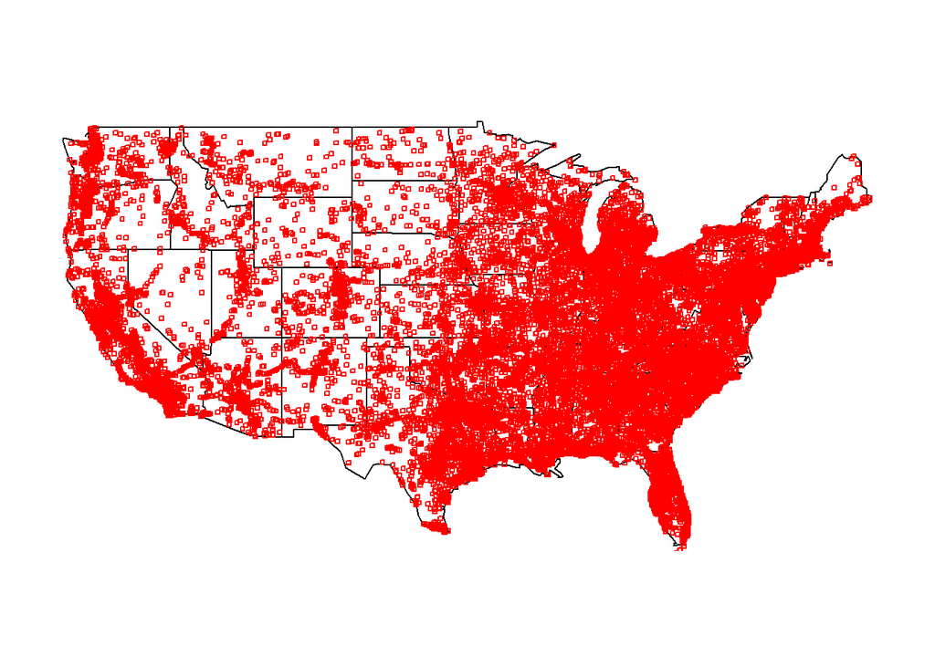

```r
if (!require("maps")) install.packages("maps"); library("maps")

map(database="state")
symbols(accident_data$LONGITUD, accident_data$LATITUDE, fg = 'red', squares = rep(1, length(accident_data$LONGITUD)), inches=0.03, add=TRUE)
```

Com podem veure, la majoria dels accidents han passat en els estats de l’est i en les zones més properes a la costa oest. Això segurament es deu a que són les zones més poblades del país.

Per comprovar-ho, cal afegir les dades de població de cada estat. Les dades han sigut extretes de la web del [census del govern dels EUA](https://www.census.gov/data/tables/time-series/demo/popest/2020s-state-total.html) i emmagatzemades en un fitxer `.csv`.

En aquest tros de codi es calcula el nombre d’accidents totals per estat, la població de cada estat i finalment, la proporció d’accidents per milió que hi ha a cada estat.

```r
if (!require("dplyr")) install.packages("dplyr"); library("dplyr")

path <- "../data/us_states_population.csv"
states_population <- read.csv(path, row.names = NULL)
states_population
```

```
##               STATENAME POPULATION
## 1               Alabama    5024279
## 2                Alaska     733391
## 3               Arizona    7151502
## 4              Arkansas    3011524
## 5            California   39538223
## 6              Colorado    5773714
## 7           Connecticut    3605944
## 8              Delaware     989948
## 9  District of Columbia     689545
## 10              Florida   21538187
## 11              Georgia   10711908
## 12               Hawaii    1455271
## 13                Idaho    1839106
## 14             Illinois   12812508
```

[output cut: 38 more lines]

```r
states_count <- accident_data %>% group_by(STATENAME) %>% tally()
states_data <- data.frame(STATENAME = states_count$STATENAME, COUNT = states_count$n)
states_data <- merge(states_data, states_population, by="STATENAME")
states_data$ACCIDENT_PROPORTION <- (states_data$COUNT / states_data$POPULATION)*1000000
states_data <- states_data[order(-states_data$ACCIDENT_PROPORTION), ]
head(states_data)
```

```
##         STATENAME COUNT POPULATION ACCIDENT_PROPORTION
## 25    Mississippi   687    2961279            231.9944
## 51        Wyoming   114     576851            197.6247
## 4        Arkansas   585    3011524            194.2538
## 41 South Carolina   962    5118425            187.9484
## 27        Montana   190    1084225            175.2404
## 32     New Mexico   365    2117522            172.3713
```

Com es pot observar, els estats on es produeixen més accidents per habitant són Mississippi, Wyoming, Arkansas, South Carolina, Montana i New Mexico.

## 2.5 Distribució dels atributs

En una anàlisi de les dades, és important també conèixer com estan distribuides.

Per això, a continuació es mostren histogrames d’algunes de les variables numèriques.

```r
if (!require("ggplot2")) install.packages("ggplot2"); library("ggplot2")
if (!require("Rmisc")) install.packages("Rmisc"); library("Rmisc")
if (!require("dplyr")) install.packages("dplyr"); library("dplyr")
if (!require("xfun")) install.packages("xfun"); library("xfun")
```

### 2.5.1 Defuncions i conductors beguts

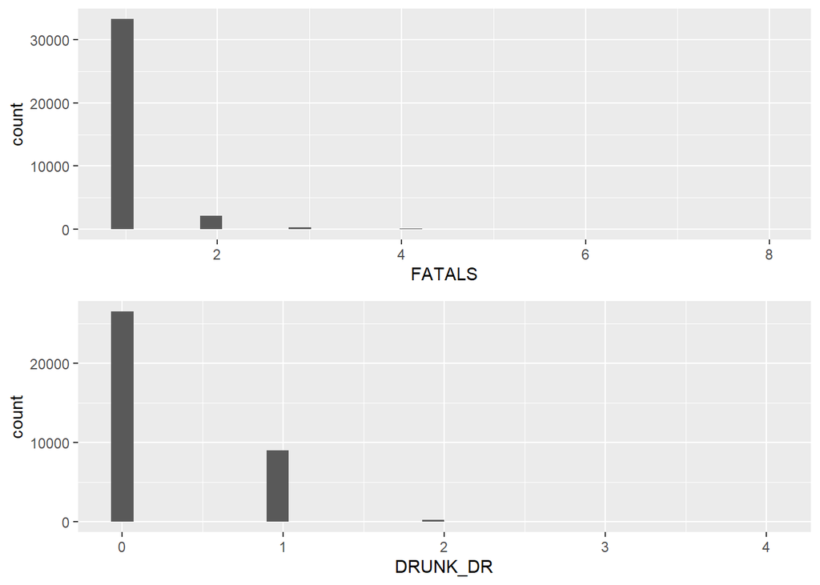

```r
histList <- list()

dist_attr <- c("FATALS", "DRUNK_DR")
accident_data_aux <- accident_data[, which(names(accident_data) %in% dist_attr)]
for(i in 1:ncol(accident_data_aux)){
  col <- names(accident_data_aux)[i]
  ggp <- ggplot(accident_data_aux, aes_string(x = col)) +
    geom_histogram(bins = 30, ggtittle = "Comptador d'ocurrències per variable")
      histList[[i]] <- ggp  # afegim cada plot a la llista buida
}
multiplot(plotlist = histList, cols = 1)
```

Seguint l’exemple de l’exercici 2 es pot pintar dos (o més) gràfiques alhora.

Això permet veure que la gran majoria d’accidents només tenen una defunció. I també que en la màjoria d’accidents no hi cap conductor implicat. També es pot veure que és molt complicat que hi hagi més d’un conductor begut en el mateix accident.

### 2.5.2 Persones i vehicles implicats

```r
histList <- list()

dist_attr <- c("PERSONS", "VE_TOTAL")
accident_data_aux <- accident_data[, which(names(accident_data) %in% dist_attr)]
head(accident_data_aux)
```

```
##   VE_TOTAL PERSONS
## 1        1       4
## 2        4       6
## 3        2       2
## 4        1       5
## 5        1       1
## 6        2       3
```

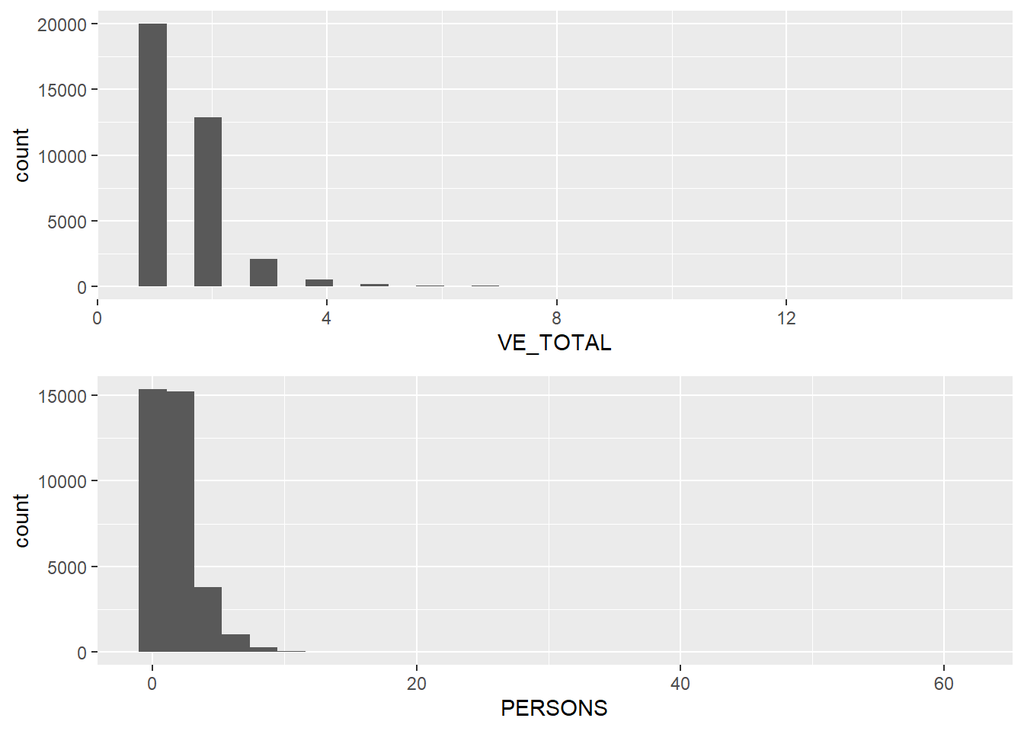

```r
for(i in 1:ncol(accident_data_aux)){
  col <- names(accident_data_aux)[i]
  ggp <- ggplot(accident_data_aux, aes_string(x = col)) +
    geom_histogram(bins = 30, ggtittle = "Comptador d'ocurrències per variable")
      histList[[i]] <- ggp  # afegim cada plot a la llista buida
}
multiplot(plotlist = histList, cols = 1)
```

En aquests casos la distribució també tendeix cap a l’esquerra. En el cas de persones implicades i de vehicles implicats, la majoria d’accidents en tenen una o dos.

Aquest fet sembla totalment lògic, perquè normalment no hi acostuma a haver-hi accidents mortals amb gaires vehicles imlicats. I excepte en casos puntuals (hi ha vianants implicats), el nombre de vehicles determina el nombre de persones implicades en un accident.

### 2.5.3 Temps d’arribada dels serveis d’emergències i temps d’arribada als hospitals

Abans s’ha calculat dos variables noves. Ara és el moment de comprovar quina informació contenen.

```r
histList <- list()

dist_attr <- c("DTIME_CRASH_ARRIVAL", "DTIME_CRASH_HOSPITAL")
accident_data_aux <- accident_data[, which(names(accident_data) %in% dist_attr)]
head(accident_data_aux)
```

```
##   DTIME_CRASH_ARRIVAL DTIME_CRASH_HOSPITAL
## 1                  12                   NA
## 2                   8                   NA
## 3                  20                   NA
## 4                  NA                   NA
## 5                  10                   NA
## 6                  24                  116
```

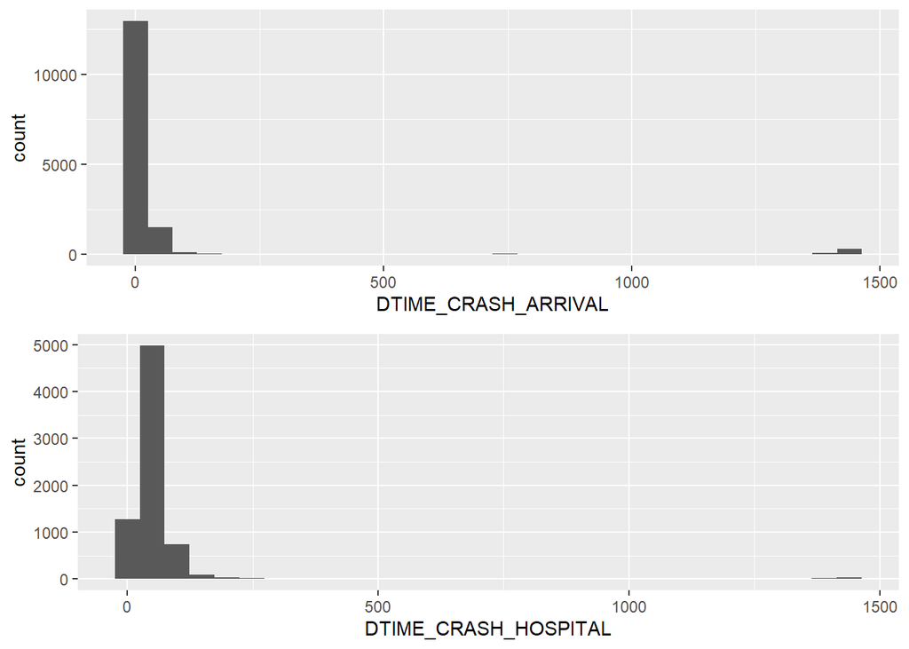

```r
for(i in 1:ncol(accident_data_aux)){
  col <- names(accident_data_aux)[i]
  ggp <- ggplot(accident_data_aux, aes_string(x = col)) +
    geom_histogram(bins = 30, ggtittle = "Comptador d'ocurrències per variable")
      histList[[i]] <- ggp  # afegim cada plot a la llista buida
}
multiplot(plotlist = histList, cols = 1)
```

Com en el cas anterior, s’estan analitzant dos variables que tenen molt a veure entre elles. És lògic veure que les seves distribucions són molt similars.

Es veu que en la majoria de casos els temps són entre `0` i `250` minuts. Però, també es poden observar valors extrems rn que el temps d’arribada està a prop dels `1500` minuts (25 hores).

Cal anar en compte amb aquests casos, ja que, és possible que sigui un error de càlcul o de trascripció de les dades.

### 2.5.4 Moment del dia

També és interessant saber en quin moment del dia es produeixen més accidents.

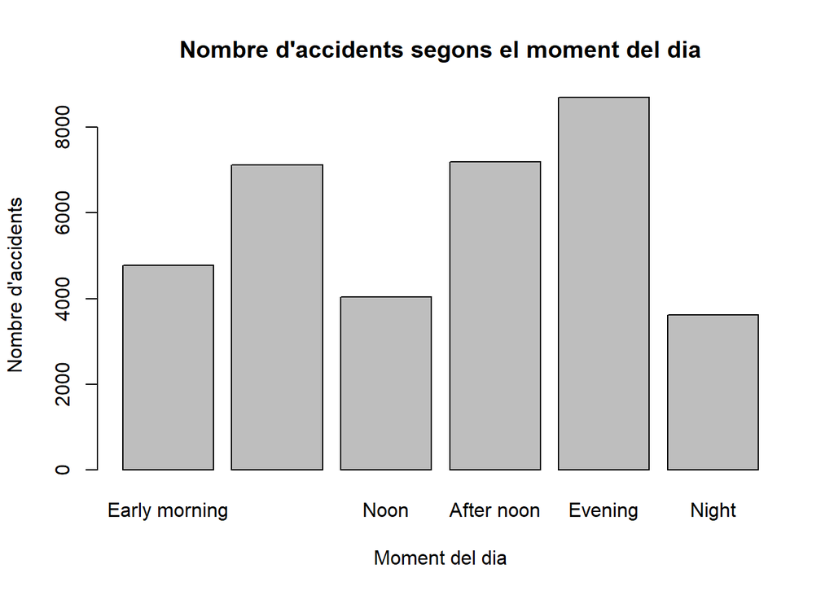

```r
plot(accident_data$HOUR_MOMENTNAME, main="Nombre d'accidents segons el moment del dia", xlab="Moment del dia", ylab="Nombre d'accidents")
```

### 2.5.5 Dia de la setmana

El dia de la setmana també pot ser important de cara que hi hagi més accidents.

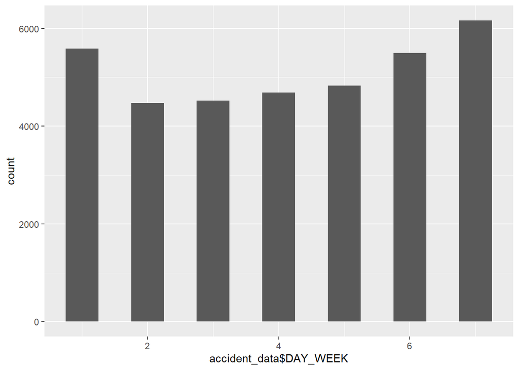

```r
ggplot(accident_data, aes(x=accident_data$DAY_WEEK)) + geom_histogram(binwidth=.5)
```

Podem veure com els divendres, els dissabtes i els diumenges hi ha més accidents mortals que la resta de dies. Això es pot deure a que els caps de setmana que hi ha més trànsit.

## 2.6 Correlacions entre atributs

Es vol veure quines variables estan relacionades entre si. El que interessa es veure com afecten les diferents variables al nombre de morts de l’accident.

### 2.6.1 Matriu de correlació

```r
remove_attr = c("STATE", "ST_CASE", "PEDS", "COUNTY", "CITY", "DAY", "MONTH", "YEAR", "DAY_WEEK", "HOUR", "MINUTE",
                "NHS", "ROUTE", "FUNC_SYS", "RD_OWNER", "MILEPT", "LATITUDE", "LONGITUD", "SP_JUR", "RELJCT1",
                "RELJCT2", "TYP_INT", "REL_ROAD", "SCH_BUS", "NOT_HOUR", "NOT_MIN", "ARR_HOUR", "ARR_MIN", "HOSP_HR",
                "HOSP_MN", "HOUR_MOMENT", "VE_FORMS", "MAN_COLL", "WRK_ZONE", "LGT_COND", "DTIME_CRASH_HOSPITAL",
                "PERNOTMVIT", "PERMVIT", "DTIME_CRASH_ARRIVAL")
accident_data_corr <- accident_data_numeric[, -which(names(accident_data_numeric) %in% remove_attr)]
str(accident_data_corr)
```

```
## 'data.frame':    35766 obs. of  8 variables:
##  $ VE_TOTAL: int  1 4 2 1 1 2 1 2 2 2 ...
##  $ PVH_INVL: int  0 0 0 0 0 0 0 0 0 0 ...
##  $ PERSONS : int  4 6 2 5 1 3 1 2 4 3 ...
##  $ RUR_URB : int  1 2 1 1 1 1 2 1 1 1 ...
##  $ HARM_EV : int  42 12 34 42 42 12 8 12 12 12 ...
##  $ WEATHER : int  1 2 2 10 2 1 1 1 10 10 ...
##  $ FATALS  : int  3 1 1 1 1 1 1 1 1 1 ...
##  $ DRUNK_DR: int  1 0 0 0 0 0 0 0 0 0 ...
```

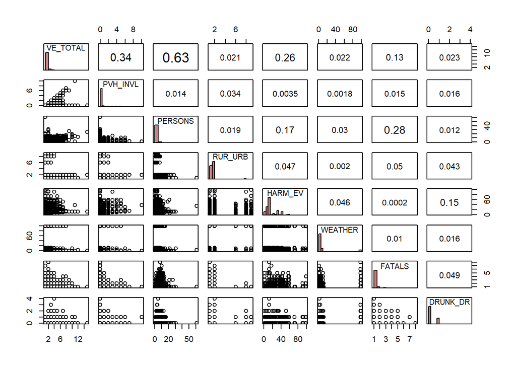

```r
panel_hist <- function(x, ...) {
    # https://r-coder.com/correlation-plot-r/
    usr <- par("usr")
    on.exit(par(usr))
    par(usr = c(usr[1:2], 0, 1.5))
    his <- hist(x, plot = FALSE)
    breaks <- his$breaks
    nB <- length(breaks)
    y <- his$counts
    y <- y/max(y)
    rect(breaks[-nB], 0, breaks[-1], y, col = rgb(0.8, 0.5, 0.5, alpha = 1.0), ...)
    # lines(density(x), col = 2, lwd = 2) # Uncomment to add density lines
}

panel_corr <- function(x, y, digits = 2, prefix = "", cex.cor, ...) {
    # https://r-coder.com/correlation-plot-r/
    usr <- par("usr")
    on.exit(par(usr))
    par(usr = c(0, 1, 0, 1))
    Cor <- abs(cor(x, y)) # Remove abs function if desired
    txt <- paste0(prefix, format(c(Cor, 0.123456789), digits = digits)[1])
    if(missing(cex.cor)) {
        cex.cor <- 0.4 / strwidth(txt)
    }
    text(0.5, 0.5, txt,
         cex = 1 + cex.cor * Cor) # Resize the text by level of correlation
}

# Plot correlation matrix
pairs(accident_data_corr,
      upper.panel = panel_corr,
      diag.panel = panel_hist)
```

### 2.6.2 Meteorologia

També és interessant saber si la meteorologia pot jugar un factor important en el nombre de morts.

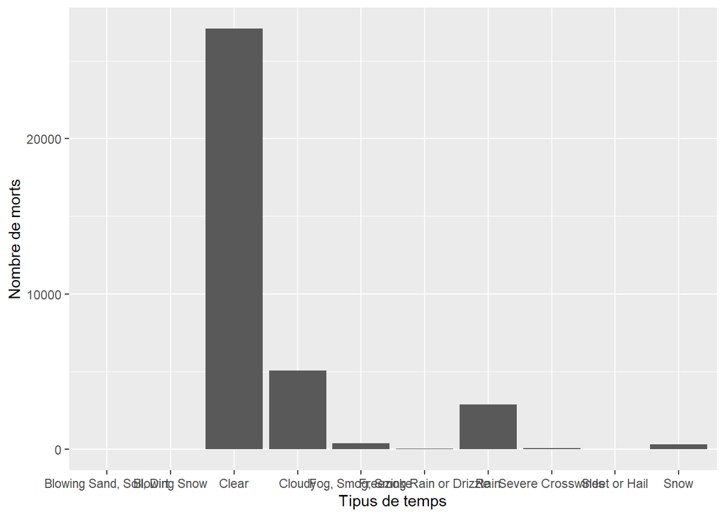

```r
remove_weather <- c("Reported as Unknown", "Not Reported", "Other")
accident_data_weather <- accident_data[-which(accident_data$WEATHERNAME %in% remove_weather), ]

ggplot(accident_data_weather, aes(x = accident_data_weather$WEATHERNAME, y = accident_data_weather$FATALS)) +
  geom_histogram(stat = "identity") +
  labs(x = "Tipus de temps", y = "Nombre de morts")
```

Com podem observar, la majoria de morts es produeixen quan està seré, però això és evident, ja que és així la majoria de dies. Podem veure també que hi ha més morts quan està embromat que quan plou, però es pot deure al mateix motiu.

Caldria estudiar la climatologia del país i els estats per poder-ne treure conclusions.

## 2.7 Conclusions

Aquest projecte de mineria de dades ha servit per estudiar superficialment les dades del FARS referents als accidents de trànsit mortals als Estats Units. En el cas d’aquest estudi s’ha fet servir dades de l’any 2020.

En les dades hi ha registres dels accidents de trànsit amb mínim un mort. Després de revisar les dades es pot dir que semblen un molt bon conjunt per a treballar. Els camps han sigut tractats prèviament i sembla que s’han corregit molt bé els possibles errors. Sorprén, que a part de la qualitat de les dades, es disposi d’una gran quantitat de registres i de diferents anys. A més, en diverses taules hi ha informació derivada de cada accident mortal.

Durant l’anàlisi s’ha pogut veure que els caps de setmana hi ha més accidents mortals, possiblement es deu al fet que més gent es deplaça per anar de vacances. En un futur treball, es podria estudiar si aquesta observació també es compleix els dies festius i en llocs on la gent acostuma a fer vacances.

S’ha pogut observar que els estats de Mississippi, Wyoming, Arkansas, South Carolina, Montana i New Mexico tenen una proporció més alta d’accidents mortals que la resta. A primera vista es pot pensar que el fet que siguin estats més rurals pot tenir quelcom a veure. Caldria comprovar si tenen pitjors carreteres o els serveis d’emergència tarden més en arribar.

Com ja s’ha comentat per donar respostes sòlides a per què passen els accidents mortals caldria fer una anàlisi molt més profunda. Però, aquesta primera aproximació, permet comprendre molt millor les dades i saber cap on anar en futurs projectes.